# Fraud

Arjun Chattoraj

## 1 Introduction

The Working Directory has been set to the folder that contains the `creditcard.csv` dataset.

### 1.1 Libraries

```r
library(tidyverse)
```

```r
library(corrplot)
library(rpart)
library(rpart.plot)
library(caTools)
library(caret)
library(e1071)
library(randomForest)
```

## 2 The dataset

### 2.1 Loading the data

Let’s start by reading in the dataset into our workspace.

```r
creditcard = read.csv("creditcard.csv")
```

### 2.2 Describing the data

This dataset has 284807 rows and 31 columns. This is a substantial dataset, so we should look at the head and see how we can start.

```r
head(creditcard)
```

```
##   Time         V1          V2        V3         V4          V5          V6
## 1    0 -1.3598071 -0.07278117 2.5363467  1.3781552 -0.33832077  0.46238778
## 2    0  1.1918571  0.26615071 0.1664801  0.4481541  0.06001765 -0.08236081
## 3    1 -1.3583541 -1.34016307 1.7732093  0.3797796 -0.50319813  1.80049938
## 4    1 -0.9662717 -0.18522601 1.7929933 -0.8632913 -0.01030888  1.24720317
## 5    2 -1.1582331  0.87773675 1.5487178  0.4030339 -0.40719338  0.09592146
## 6    2 -0.4259659  0.96052304 1.1411093 -0.1682521  0.42098688 -0.02972755
##            V7          V8         V9         V10        V11         V12
## 1  0.23959855  0.09869790  0.3637870  0.09079417 -0.5515995 -0.61780086
## 2 -0.07880298  0.08510165 -0.2554251 -0.16697441  1.6127267  1.06523531
## 3  0.79146096  0.24767579 -1.5146543  0.20764287  0.6245015  0.06608369
## 4  0.23760894  0.37743587 -1.3870241 -0.05495192 -0.2264873  0.17822823
## 5  0.59294075 -0.27053268  0.8177393  0.75307443 -0.8228429  0.53819555
## 6  0.47620095  0.26031433 -0.5686714 -0.37140720  1.3412620  0.35989384
##          V13        V14        V15        V16         V17         V18
```

[output cut: 20 more lines]

```r
colnames(creditcard)
```

```
##  [1] "Time"   "V1"     "V2"     "V3"     "V4"     "V5"     "V6"
##  [8] "V7"     "V8"     "V9"     "V10"    "V11"    "V12"    "V13"
## [15] "V14"    "V15"    "V16"    "V17"    "V18"    "V19"    "V20"
## [22] "V21"    "V22"    "V23"    "V24"    "V25"    "V26"    "V27"
## [29] "V28"    "Amount" "Class"
```

The interesting thing to note is that the columns of factors are only noted as $V_n$ so we cannot use intuition to find link between variables, but use the relationships between each to try to do any analysis.

Another thing to notice is that the times are often repeated, but are not continuous.

The last column, class states if the row is one of fraud or not.

Let’s use the *summary* function to check for missing values

```r
summary(creditcard)
```

```
##       Time              V1                  V2
##  Min.   :     0   Min.   :-56.40751   Min.   :-72.71573
##  1st Qu.: 54202   1st Qu.: -0.92037   1st Qu.: -0.59855
##  Median : 84692   Median :  0.01811   Median :  0.06549
##  Mean   : 94814   Mean   :  0.00000   Mean   :  0.00000
##  3rd Qu.:139321   3rd Qu.:  1.31564   3rd Qu.:  0.80372
##  Max.   :172792   Max.   :  2.45493   Max.   : 22.05773
##        V3                 V4                 V5
##  Min.   :-48.3256   Min.   :-5.68317   Min.   :-113.74331
##  1st Qu.: -0.8904   1st Qu.:-0.84864   1st Qu.:  -0.69160
##  Median :  0.1799   Median :-0.01985   Median :  -0.05434
##  Mean   :  0.0000   Mean   : 0.00000   Mean   :   0.00000
##  3rd Qu.:  1.0272   3rd Qu.: 0.74334   3rd Qu.:   0.61193
##  Max.   :  9.3826   Max.   :16.87534   Max.   :  34.80167
##        V6                 V7                 V8
##  Min.   :-26.1605   Min.   :-43.5572   Min.   :-73.21672
##  1st Qu.: -0.7683   1st Qu.: -0.5541   1st Qu.: -0.20863
##  Median : -0.2742   Median :  0.0401   Median :  0.02236
##  Mean   :  0.0000   Mean   :  0.0000   Mean   :  0.00000
##  3rd Qu.:  0.3986   3rd Qu.:  0.5704   3rd Qu.:  0.32735
##  Max.   : 73.3016   Max.   :120.5895   Max.   : 20.00721
##        V9                 V10                 V11
##  Min.   :-13.43407   Min.   :-24.58826   Min.   :-4.79747
##  1st Qu.: -0.64310   1st Qu.: -0.53543   1st Qu.:-0.76249
##  Median : -0.05143   Median : -0.09292   Median :-0.03276
##  Mean   :  0.00000   Mean   :  0.00000   Mean   : 0.00000
##  3rd Qu.:  0.59714   3rd Qu.:  0.45392   3rd Qu.: 0.73959
##  Max.   : 15.59500   Max.   : 23.74514   Max.   :12.01891
##       V12                V13                V14
##  Min.   :-18.6837   Min.   :-5.79188   Min.   :-19.2143
##  1st Qu.: -0.4056   1st Qu.:-0.64854   1st Qu.: -0.4256
##  Median :  0.1400   Median :-0.01357   Median :  0.0506
##  Mean   :  0.0000   Mean   : 0.00000   Mean   :  0.0000
##  3rd Qu.:  0.6182   3rd Qu.: 0.66251   3rd Qu.:  0.4931
##  Max.   :  7.8484   Max.   : 7.12688   Max.   : 10.5268
##       V15                V16                 V17
##  Min.   :-4.49894   Min.   :-14.12985   Min.   :-25.16280
##  1st Qu.:-0.58288   1st Qu.: -0.46804   1st Qu.: -0.48375
##  Median : 0.04807   Median :  0.06641   Median : -0.06568
##  Mean   : 0.00000   Mean   :  0.00000   Mean   :  0.00000
```

[output cut: 22 more lines]

```
##  Max.   : 4.58455   Max.   :  7.51959   Max.   : 3.51735
##       V27                  V28                Amount
##  Min.   :-22.565679   Min.   :-15.43008   Min.   :    0.00
##  1st Qu.: -0.070840   1st Qu.: -0.05296   1st Qu.:    5.60
##  Median :  0.001342   Median :  0.01124   Median :   22.00
##  Mean   :  0.000000   Mean   :  0.00000   Mean   :   88.35
##  3rd Qu.:  0.091045   3rd Qu.:  0.07828   3rd Qu.:   77.17
##  Max.   : 31.612198   Max.   : 33.84781   Max.   :25691.16
##      Class
##  Min.   :0.000000
##  1st Qu.:0.000000
##  Median :0.000000
##  Mean   :0.001728
##  3rd Qu.:0.000000
##  Max.   :1.000000
```

**There are no missing values!**

## 3 Data Management

### 3.1 Dealing with missing values

*LOL*

### 3.2 Labeling factors

```r
creditcard$Class <- as.factor(creditcard$Class)
```

## 4 Data visualization

### 4.1 Correlation

We’ll look at the correlation between variables.

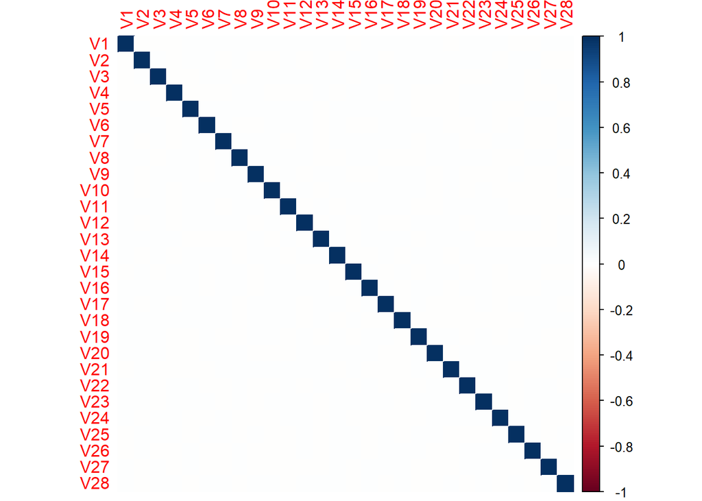

```r
corr.mat = creditcard %>%
                select(starts_with("V")) %>%
                cor()

corrplot(corr.mat, method = "color")
```

Okay, the variables are utterly uncorrelated.

## 5 Predictive modelling

### 5.1 Train/test split

We need to split the data into one training dataset and one testing dataset. We’ll keep it a typical 70/30 split.

```r
set.seed(7)
splitData <- sample.split(creditcard$Class, SplitRatio = 0.7)
train <- subset(creditcard, splitData == T)
test <- subset(creditcard, splitData == F)

table(test$Class)
```

```
##
##     0     1
## 85295   148
```

### 5.2 Baseline accuracy

```r
sum(test$Class == 0)/length(test$Class)
```

```
## [1] 0.9982679
```

With a seed of 7, the baseline accuracy is 99.82679%

### 5.3 Accuracy function

We also need an accuracy function. This is fairly simple to write. If we are given two vectors of binary data, we can simply find the number of times the values are different. We can make it so that we return the accuracy in a nice format.

```r
accuracy = function(predicted, testing){
    acc = sum(predicted == testing)/length(testing) * 100
    paste0("The accuracy of this model is: ", acc, "%")
}
```

Let’s do a quick test with the baseline model

```r
baseline = rep(0,length(test$Class))

accuracy(baseline,test$Class)
```

```
## [1] "The accuracy of this model is: 99.8267851082008%"
```

Cool. It matches. Let’s move on.

### 5.4 Random guess

#### 5.4.1 Without replacement

This model looks at the percent of 0’s and 1’s in the training data, and randomly guesses whether it is a 0 or 1.

```r
zeros.per = sum(train$Class == 0)/length(train$Class)
per.vec = c(rep(0,length(test$Class)*zeros.per+1),rep(1,length(test$Class)*(1-zeros.per)))

rand1 = sample(per.vec,length(per.vec),replace = FALSE)
```

#### 5.4.2 Accuracy test

```r
accuracy(rand1,test$Class)
```

```
## [1] "The accuracy of this model is: 99.6547405872921%"
```

#### 5.4.3 With replacement

```r
rand2 = sample(per.vec,length(per.vec),replace = TRUE)
```

#### 5.4.2 Accuracy test

```r
accuracy(rand2,test$Class)
```

```
## [1] "The accuracy of this model is: 99.6512294746205%"
```

Well then, seems like guessing is a worse choice than saying they are all 0.

### 5.5 Logistic Regression model

```r
glm.model <- glm(Class ~ ., data = train, family = "binomial")
glm.predict = predict(glm.model, test, type = "response")

glm.predict.binary = rep(0,length(glm.predict))
for(i in 1:length(glm.predict)){
    if(glm.predict[i] > 0.5){
        glm.predict.binary[i] = 1
    } else {
        glm.predict.binary[i] = 0
    }
}

table(test$Class, glm.predict > 0.5)
```

```
##
##     FALSE  TRUE
##   0 85284    11
##   1    60    88
```

#### 5.5.1 Accuracy

```r
accuracy(glm.predict.binary,test$Class)
```

```
## [1] "The accuracy of this model is: 99.916903666772%"
```

### 5.6 Decision Tree model

```r
DT <- rpart(Class ~ ., data = train, method = "class")
```

Plot of the Decision Tree

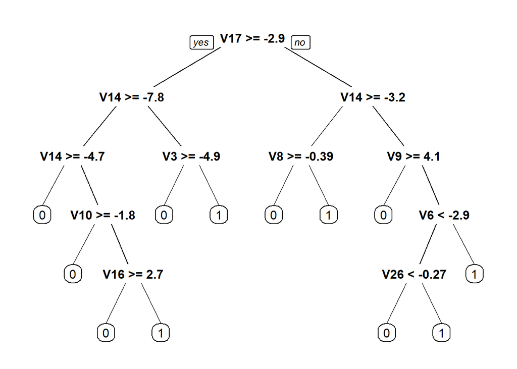

```r
prp(DT)
```

```r
DT.predict = predict(DT, test, type = "class")
```

#### 5.6.1 Accuracy

```r
accuracy(DT.predict, test$Class)
```

```
## [1] "The accuracy of this model is: 99.9531851643786%"
```

```r
confusionMatrix(test$Class, DT.predict)
```

```
## Confusion Matrix and Statistics
##
##           Reference
## Prediction     0     1
##          0 85286     9
##          1    31   117
##
##                Accuracy : 0.9995
##                  95% CI : (0.9994, 0.9997)
##     No Information Rate : 0.9985
##     P-Value [Acc > NIR] : < 2.2e-16
##
##                   Kappa : 0.8538
##  Mcnemar's Test P-Value : 0.0008989
##
##             Sensitivity : 0.9996
##             Specificity : 0.9286
##          Pos Pred Value : 0.9999
##          Neg Pred Value : 0.7905
##              Prevalence : 0.9985
##          Detection Rate : 0.9982
##    Detection Prevalence : 0.9983
##       Balanced Accuracy : 0.9641
##
##        'Positive' Class : 0
##
```

## 6 Conclusions

This dataset was helpful for me. As this is one of the earliest model building exercises I have undertaken, it was very useful in learning about different models, and also developing strategies in model building.

However, I am more than aware that there is a **major** flaw in the methods used. Due to the unbalanced nature of the dataset (with so many 0 values vs 1 values) It is incredible easy to get high accuracy rates, so other methods need to be taken.

One could be partitioning the data more. If the ratio of 0’s to 1’s is lowered, we can get a better understanding of what causes the 1’s.

Also, there are other methods. Many on *Kaggle* have listed methods called *SMOTE*, or *ROSE*. However, I yet do not have the knowledge of these methods, but I will continue learning and educate myself regarding the uses of these models.

At the end of the day, this was a fun experience. It helped me grow and gain experience.

Massive thanks to Amandeep Rathee. His kernel on Kaggle was helpful in gaining ideas on different models and going through the dataset.